# Risk Factor Analysis

## Outcome Variable

**Outcome Variable:** pers_wast

## Predictor Variables

**Intervention Variable:** sex

**Adjustment Set:**

unadjusted

## Stratifying Variables

The analysis was stratified on these variable(s):

- agecat
- studyid
- country

## Data Summary

| agecat | studyid | country | sex | pers_wast | n_cell | n |
| --- | --- | --- | --- | --- | --- | --- |
| 0-24 months | CMC-V-BCS-2002 | INDIA | Female | 0 | 179 | 373 |
| 0-24 months | CMC-V-BCS-2002 | INDIA | Female | 1 | 8 | 373 |
| 0-24 months | CMC-V-BCS-2002 | INDIA | Male | 0 | 171 | 373 |
| 0-24 months | CMC-V-BCS-2002 | INDIA | Male | 1 | 15 | 373 |
| 0-24 months | CMIN | BANGLADESH | Female | 0 | 102 | 257 |
| 0-24 months | CMIN | BANGLADESH | Female | 1 | 7 | 257 |
| 0-24 months | CMIN | BANGLADESH | Male | 0 | 135 | 257 |
| 0-24 months | CMIN | BANGLADESH | Male | 1 | 13 | 257 |
| 0-24 months | COHORTS | GUATEMALA | Female | 0 | 490 | 1056 |
| 0-24 months | COHORTS | GUATEMALA | Female | 1 | 12 | 1056 |
| 0-24 months | COHORTS | GUATEMALA | Male | 0 | 530 | 1056 |
| 0-24 months | COHORTS | GUATEMALA | Male | 1 | 24 | 1056 |
| 0-24 months | COHORTS | INDIA | Female | 0 | 2511 | 5705 |
| 0-24 months | COHORTS | INDIA | Female | 1 | 253 | 5705 |
| 0-24 months | COHORTS | INDIA | Male | 0 | 2644 | 5705 |
| 0-24 months | COHORTS | INDIA | Male | 1 | 297 | 5705 |
| 0-24 months | COHORTS | PHILIPPINES | Female | 0 | 1276 | 2811 |
| 0-24 months | COHORTS | PHILIPPINES | Female | 1 | 53 | 2811 |
| 0-24 months | COHORTS | PHILIPPINES | Male | 0 | 1391 | 2811 |
| 0-24 months | COHORTS | PHILIPPINES | Male | 1 | 91 | 2811 |
| 0-24 months | CONTENT | PERU | Female | 0 | 109 | 215 |
| 0-24 months | CONTENT | PERU | Female | 1 | 0 | 215 |
| 0-24 months | CONTENT | PERU | Male | 0 | 106 | 215 |
| 0-24 months | CONTENT | PERU | Male | 1 | 0 | 215 |
| 0-24 months | EE | PAKISTAN | Female | 0 | 168 | 377 |
| 0-24 months | EE | PAKISTAN | Female | 1 | 14 | 377 |
| 0-24 months | EE | PAKISTAN | Male | 0 | 176 | 377 |
| 0-24 months | EE | PAKISTAN | Male | 1 | 19 | 377 |
| 0-24 months | GMS-Nepal | NEPAL | Female | 0 | 251 | 597 |
| 0-24 months | GMS-Nepal | NEPAL | Female | 1 | 36 | 597 |

[output cut: 310 more lines]

The following strata were considered:

- agecat: 0-24 months, studyid: CMC-V-BCS-2002, country: INDIA
- agecat: 0-24 months, studyid: CMIN, country: BANGLADESH
- agecat: 0-24 months, studyid: COHORTS, country: GUATEMALA
- agecat: 0-24 months, studyid: COHORTS, country: INDIA
- agecat: 0-24 months, studyid: COHORTS, country: PHILIPPINES
- agecat: 0-24 months, studyid: CONTENT, country: PERU
- agecat: 0-24 months, studyid: EE, country: PAKISTAN
- agecat: 0-24 months, studyid: GMS-Nepal, country: NEPAL
- agecat: 0-24 months, studyid: Guatemala BSC, country: GUATEMALA
- agecat: 0-24 months, studyid: iLiNS-Zinc, country: BURKINA FASO
- agecat: 0-24 months, studyid: IRC, country: INDIA
- agecat: 0-24 months, studyid: JiVitA-3, country: BANGLADESH
- agecat: 0-24 months, studyid: JiVitA-4, country: BANGLADESH
- agecat: 0-24 months, studyid: Keneba, country: GAMBIA
- agecat: 0-24 months, studyid: LCNI-5, country: MALAWI
- agecat: 0-24 months, studyid: MAL-ED, country: BANGLADESH
- agecat: 0-24 months, studyid: MAL-ED, country: BRAZIL
- agecat: 0-24 months, studyid: MAL-ED, country: INDIA
- agecat: 0-24 months, studyid: MAL-ED, country: NEPAL
- agecat: 0-24 months, studyid: MAL-ED, country: PERU
- agecat: 0-24 months, studyid: MAL-ED, country: SOUTH AFRICA
- agecat: 0-24 months, studyid: MAL-ED, country: TANZANIA, UNITED REPUBLIC OF
- agecat: 0-24 months, studyid: NIH-Birth, country: BANGLADESH
- agecat: 0-24 months, studyid: NIH-Crypto, country: BANGLADESH
- agecat: 0-24 months, studyid: PROBIT, country: BELARUS
- agecat: 0-24 months, studyid: PROVIDE, country: BANGLADESH
- agecat: 0-24 months, studyid: ResPak, country: PAKISTAN
- agecat: 0-24 months, studyid: SAS-CompFeed, country: INDIA
- agecat: 0-24 months, studyid: SAS-FoodSuppl, country: INDIA
- agecat: 0-24 months, studyid: TanzaniaChild2, country: TANZANIA, UNITED REPUBLIC OF
- agecat: 0-24 months, studyid: ZVITAMBO, country: ZIMBABWE
- agecat: 0-6 months, studyid: CMC-V-BCS-2002, country: INDIA
- agecat: 0-6 months, studyid: CMIN, country: BANGLADESH
- agecat: 0-6 months, studyid: COHORTS, country: PHILIPPINES
- agecat: 0-6 months, studyid: CONTENT, country: PERU
- agecat: 0-6 months, studyid: EE, country: PAKISTAN
- agecat: 0-6 months, studyid: GMS-Nepal, country: NEPAL
- agecat: 0-6 months, studyid: IRC, country: INDIA
- agecat: 0-6 months, studyid: JiVitA-3, country: BANGLADESH
- agecat: 0-6 months, studyid: Keneba, country: GAMBIA
- agecat: 0-6 months, studyid: MAL-ED, country: BANGLADESH
- agecat: 0-6 months, studyid: MAL-ED, country: BRAZIL
- agecat: 0-6 months, studyid: MAL-ED, country: INDIA
- agecat: 0-6 months, studyid: MAL-ED, country: NEPAL
- agecat: 0-6 months, studyid: MAL-ED, country: PERU
- agecat: 0-6 months, studyid: MAL-ED, country: SOUTH AFRICA
- agecat: 0-6 months, studyid: MAL-ED, country: TANZANIA, UNITED REPUBLIC OF
- agecat: 0-6 months, studyid: NIH-Birth, country: BANGLADESH
- agecat: 0-6 months, studyid: NIH-Crypto, country: BANGLADESH
- agecat: 0-6 months, studyid: PROBIT, country: BELARUS
- agecat: 0-6 months, studyid: PROVIDE, country: BANGLADESH
- agecat: 0-6 months, studyid: ResPak, country: PAKISTAN
- agecat: 0-6 months, studyid: TanzaniaChild2, country: TANZANIA, UNITED REPUBLIC OF
- agecat: 0-6 months, studyid: ZVITAMBO, country: ZIMBABWE
- agecat: 6-24 months, studyid: CMC-V-BCS-2002, country: INDIA
- agecat: 6-24 months, studyid: CMIN, country: BANGLADESH
- agecat: 6-24 months, studyid: COHORTS, country: GUATEMALA
- agecat: 6-24 months, studyid: COHORTS, country: INDIA
- agecat: 6-24 months, studyid: COHORTS, country: PHILIPPINES
- agecat: 6-24 months, studyid: CONTENT, country: PERU
- agecat: 6-24 months, studyid: EE, country: PAKISTAN
- agecat: 6-24 months, studyid: GMS-Nepal, country: NEPAL
- agecat: 6-24 months, studyid: Guatemala BSC, country: GUATEMALA
- agecat: 6-24 months, studyid: iLiNS-Zinc, country: BURKINA FASO
- agecat: 6-24 months, studyid: IRC, country: INDIA
- agecat: 6-24 months, studyid: JiVitA-3, country: BANGLADESH
- agecat: 6-24 months, studyid: JiVitA-4, country: BANGLADESH
- agecat: 6-24 months, studyid: Keneba, country: GAMBIA
- agecat: 6-24 months, studyid: LCNI-5, country: MALAWI
- agecat: 6-24 months, studyid: MAL-ED, country: BANGLADESH
- agecat: 6-24 months, studyid: MAL-ED, country: BRAZIL
- agecat: 6-24 months, studyid: MAL-ED, country: INDIA
- agecat: 6-24 months, studyid: MAL-ED, country: NEPAL
- agecat: 6-24 months, studyid: MAL-ED, country: PERU
- agecat: 6-24 months, studyid: MAL-ED, country: SOUTH AFRICA
- agecat: 6-24 months, studyid: MAL-ED, country: TANZANIA, UNITED REPUBLIC OF
- agecat: 6-24 months, studyid: NIH-Birth, country: BANGLADESH
- agecat: 6-24 months, studyid: NIH-Crypto, country: BANGLADESH
- agecat: 6-24 months, studyid: PROBIT, country: BELARUS
- agecat: 6-24 months, studyid: PROVIDE, country: BANGLADESH
- agecat: 6-24 months, studyid: ResPak, country: PAKISTAN
- agecat: 6-24 months, studyid: SAS-CompFeed, country: INDIA
- agecat: 6-24 months, studyid: SAS-FoodSuppl, country: INDIA
- agecat: 6-24 months, studyid: TanzaniaChild2, country: TANZANIA, UNITED REPUBLIC OF
- agecat: 6-24 months, studyid: ZVITAMBO, country: ZIMBABWE

### Dropped Strata

Some strata were dropped due to rare outcomes:

- agecat: 0-24 months, studyid: CONTENT, country: PERU
- agecat: 0-24 months, studyid: Guatemala BSC, country: GUATEMALA
- agecat: 0-24 months, studyid: LCNI-5, country: MALAWI
- agecat: 0-24 months, studyid: MAL-ED, country: BANGLADESH
- agecat: 0-24 months, studyid: MAL-ED, country: BRAZIL
- agecat: 0-24 months, studyid: MAL-ED, country: NEPAL
- agecat: 0-24 months, studyid: MAL-ED, country: PERU
- agecat: 0-24 months, studyid: MAL-ED, country: SOUTH AFRICA
- agecat: 0-24 months, studyid: MAL-ED, country: TANZANIA, UNITED REPUBLIC OF
- agecat: 0-6 months, studyid: CMIN, country: BANGLADESH
- agecat: 0-6 months, studyid: CONTENT, country: PERU
- agecat: 0-6 months, studyid: JiVitA-3, country: BANGLADESH
- agecat: 0-6 months, studyid: MAL-ED, country: BANGLADESH
- agecat: 0-6 months, studyid: MAL-ED, country: BRAZIL
- agecat: 0-6 months, studyid: MAL-ED, country: NEPAL
- agecat: 0-6 months, studyid: MAL-ED, country: PERU
- agecat: 0-6 months, studyid: MAL-ED, country: SOUTH AFRICA
- agecat: 0-6 months, studyid: MAL-ED, country: TANZANIA, UNITED REPUBLIC OF
- agecat: 0-6 months, studyid: NIH-Birth, country: BANGLADESH
- agecat: 0-6 months, studyid: NIH-Crypto, country: BANGLADESH
- agecat: 0-6 months, studyid: PROVIDE, country: BANGLADESH
- agecat: 0-6 months, studyid: ZVITAMBO, country: ZIMBABWE
- agecat: 6-24 months, studyid: CONTENT, country: PERU
- agecat: 6-24 months, studyid: Guatemala BSC, country: GUATEMALA
- agecat: 6-24 months, studyid: LCNI-5, country: MALAWI
- agecat: 6-24 months, studyid: MAL-ED, country: BANGLADESH
- agecat: 6-24 months, studyid: MAL-ED, country: BRAZIL
- agecat: 6-24 months, studyid: MAL-ED, country: NEPAL
- agecat: 6-24 months, studyid: MAL-ED, country: PERU
- agecat: 6-24 months, studyid: MAL-ED, country: SOUTH AFRICA
- agecat: 6-24 months, studyid: MAL-ED, country: TANZANIA, UNITED REPUBLIC OF

## Methods Detail

We’re interested in the causal parameters $E[Y_a]$ for all values of $a \in \mathcal{A}$. These parameters represent the mean outcome if, possibly contrary to fact, we intervened to set all units to have $A=a$. Under the randomization and positivity assumptions, these are identified by the statistical parameters $\psi_a=E_W[E_{Y|A,W}(Y|A=a,W)]$. In addition, we’re interested in the mean of $Y$, $E[Y]$ under no intervention (the observed mean). We will estimate these parameters by using SuperLearner to fit the relevant likelihood factors – $E_{Y|A,W}(Y|A=a,W)$ and $p(A=a|W)$, and then updating our likelihood fit using a joint TMLE.

For unadjusted analyses ($W=\{\}$), initial likelihoods were estimated using Lrnr_glm to estimate the simple $E(Y|A)$ and Lrnr_mean to estimate $p(A)$. For adjusted analyses, a small library containing Lrnr_glmnet, Lrnr_xgboost, and Lrnr_mean was used.

Having estimated these parameters, we will then use the delta method to estimate relative risks and attributable risks relative to a prespecified baseline level of $A$.

# Results Detail

## Results Plots

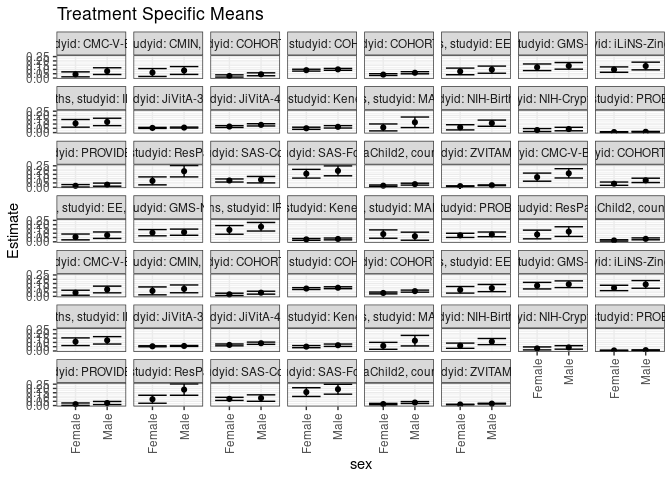

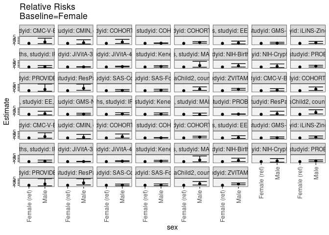

[figure not shown]

[figure not shown]

## Results Table

### Parameter: TSM

| agecat | studyid | country | intervention_level | baseline_level | estimate | ci_lower | ci_upper |
| --- | --- | --- | --- | --- | --- | --- | --- |
| 0-24 months | CMC-V-BCS-2002 | INDIA | Female | NA | 0.0427807 | 0.0137378 | 0.0718237 |
| 0-24 months | CMC-V-BCS-2002 | INDIA | Male | NA | 0.0806452 | 0.0414615 | 0.1198288 |
| 0-24 months | CMIN | BANGLADESH | Female | NA | 0.0642202 | 0.0181092 | 0.1103311 |
| 0-24 months | CMIN | BANGLADESH | Male | NA | 0.0878378 | 0.0421458 | 0.1335299 |
| 0-24 months | COHORTS | GUATEMALA | Female | NA | 0.0239044 | 0.0105358 | 0.0372730 |
| 0-24 months | COHORTS | GUATEMALA | Male | NA | 0.0433213 | 0.0263610 | 0.0602816 |
| 0-24 months | COHORTS | INDIA | Female | NA | 0.0915340 | 0.0807827 | 0.1022854 |
| 0-24 months | COHORTS | INDIA | Male | NA | 0.1009861 | 0.0900954 | 0.1118767 |
| 0-24 months | COHORTS | PHILIPPINES | Female | NA | 0.0398796 | 0.0293575 | 0.0504017 |
| 0-24 months | COHORTS | PHILIPPINES | Male | NA | 0.0614035 | 0.0491788 | 0.0736282 |
| 0-24 months | EE | PAKISTAN | Female | NA | 0.0769231 | 0.0381584 | 0.1156878 |
| 0-24 months | EE | PAKISTAN | Male | NA | 0.0974359 | 0.0557580 | 0.1391138 |
| 0-24 months | GMS-Nepal | NEPAL | Female | NA | 0.1254355 | 0.0870845 | 0.1637866 |
| 0-24 months | GMS-Nepal | NEPAL | Male | NA | 0.1419355 | 0.1030545 | 0.1808164 |
| 0-24 months | iLiNS-Zinc | BURKINA FASO | Female | NA | 0.0985222 | 0.0671712 | 0.1298731 |
| 0-24 months | iLiNS-Zinc | BURKINA FASO | Male | NA | 0.1400233 | 0.0951407 | 0.1849060 |
| 0-24 months | IRC | INDIA | Female | NA | 0.1081081 | 0.0633081 | 0.1529081 |
| 0-24 months | IRC | INDIA | Male | NA | 0.1244444 | 0.0812611 | 0.1676278 |
| 0-24 months | JiVitA-3 | BANGLADESH | Female | NA | 0.0548796 | 0.0490082 | 0.0607511 |
| 0-24 months | JiVitA-3 | BANGLADESH | Male | NA | 0.0586852 | 0.0532729 | 0.0640974 |
| 0-24 months | JiVitA-4 | BANGLADESH | Female | NA | 0.0707797 | 0.0599729 | 0.0815865 |
| 0-24 months | JiVitA-4 | BANGLADESH | Male | NA | 0.0905646 | 0.0775939 | 0.1035353 |
| 0-24 months | Keneba | GAMBIA | Female | NA | 0.0507185 | 0.0382123 | 0.0632247 |
| 0-24 months | Keneba | GAMBIA | Male | NA | 0.0674068 | 0.0535655 | 0.0812481 |
| 0-24 months | MAL-ED | INDIA | Female | NA | 0.0601504 | 0.0196580 | 0.1006428 |
| 0-24 months | MAL-ED | INDIA | Male | NA | 0.1203704 | 0.0588741 | 0.1818666 |
| 0-24 months | NIH-Birth | BANGLADESH | Female | NA | 0.0617284 | 0.0314412 | 0.0920156 |
| 0-24 months | NIH-Birth | BANGLADESH | Male | NA | 0.1099656 | 0.0739873 | 0.1459439 |
| 0-24 months | NIH-Crypto | BANGLADESH | Female | NA | 0.0298103 | 0.0124465 | 0.0471741 |
| 0-24 months | NIH-Crypto | BANGLADESH | Male | NA | 0.0415512 | 0.0209512 | 0.0621513 |

[output cut: 78 more lines]

### Parameter: E(Y)

| agecat | studyid | country | intervention_level | baseline_level | estimate | ci_lower | ci_upper |
| --- | --- | --- | --- | --- | --- | --- | --- |
| 0-24 months | CMC-V-BCS-2002 | INDIA | NA | NA | 0.0616622 | 0.0372186 | 0.0861058 |
| 0-24 months | CMIN | BANGLADESH | NA | NA | 0.0778210 | 0.0450051 | 0.1106369 |
| 0-24 months | COHORTS | GUATEMALA | NA | NA | 0.0340909 | 0.0231410 | 0.0450408 |
| 0-24 months | COHORTS | INDIA | NA | NA | 0.0964067 | 0.0887472 | 0.1040661 |
| 0-24 months | COHORTS | PHILIPPINES | NA | NA | 0.0512273 | 0.0430760 | 0.0593786 |
| 0-24 months | EE | PAKISTAN | NA | NA | 0.0875332 | 0.0589672 | 0.1160991 |
| 0-24 months | GMS-Nepal | NEPAL | NA | NA | 0.1340034 | 0.1066544 | 0.1613523 |
| 0-24 months | iLiNS-Zinc | BURKINA FASO | NA | NA | 0.1198322 | 0.0943748 | 0.1452897 |
| 0-24 months | IRC | INDIA | NA | NA | 0.1170732 | 0.0859146 | 0.1482317 |
| 0-24 months | JiVitA-3 | BANGLADESH | NA | NA | 0.0568247 | 0.0527145 | 0.0609348 |
| 0-24 months | JiVitA-4 | BANGLADESH | NA | NA | 0.0806665 | 0.0720540 | 0.0892791 |
| 0-24 months | Keneba | GAMBIA | NA | NA | 0.0593290 | 0.0499611 | 0.0686968 |
| 0-24 months | MAL-ED | INDIA | NA | NA | 0.0871369 | 0.0514552 | 0.1228187 |
| 0-24 months | NIH-Birth | BANGLADESH | NA | NA | 0.0880150 | 0.0639627 | 0.1120673 |
| 0-24 months | NIH-Crypto | BANGLADESH | NA | NA | 0.0356164 | 0.0221630 | 0.0490699 |
| 0-24 months | PROBIT | BELARUS | NA | NA | 0.0080806 | 0.0045539 | 0.0116073 |
| 0-24 months | PROVIDE | BANGLADESH | NA | NA | 0.0234009 | 0.0116889 | 0.0351130 |
| 0-24 months | ResPak | PAKISTAN | NA | NA | 0.1328125 | 0.0911588 | 0.1744662 |
| 0-24 months | SAS-CompFeed | INDIA | NA | NA | 0.0834553 | 0.0601989 | 0.1067118 |
| 0-24 months | SAS-FoodSuppl | INDIA | NA | NA | 0.1733333 | 0.1349698 | 0.2116969 |
| 0-24 months | TanzaniaChild2 | TANZANIA, UNITED REPUBLIC OF | NA | NA | 0.0267775 | 0.0199775 | 0.0335775 |
| 0-24 months | ZVITAMBO | ZIMBABWE | NA | NA | 0.0176341 | 0.0149910 | 0.0202771 |
| 0-6 months | CMC-V-BCS-2002 | INDIA | NA | NA | 0.1396648 | 0.1037072 | 0.1756225 |
| 0-6 months | COHORTS | PHILIPPINES | NA | NA | 0.0609613 | 0.0448957 | 0.0770269 |
| 0-6 months | EE | PAKISTAN | NA | NA | 0.0673854 | 0.0418419 | 0.0929290 |
| 0-6 months | GMS-Nepal | NEPAL | NA | NA | 0.1093474 | 0.0836377 | 0.1350572 |
| 0-6 months | IRC | INDIA | NA | NA | 0.1592040 | 0.1233945 | 0.1950135 |
| 0-6 months | Keneba | GAMBIA | NA | NA | 0.0308068 | 0.0233159 | 0.0382978 |
| 0-6 months | MAL-ED | INDIA | NA | NA | 0.0791667 | 0.0449364 | 0.1133970 |
| 0-6 months | PROBIT | BELARUS | NA | NA | 0.0810551 | 0.0555982 | 0.1065120 |
| 0-6 months | ResPak | PAKISTAN | NA | NA | 0.1028807 | 0.0646041 | 0.1411572 |
| 0-6 months | TanzaniaChild2 | TANZANIA, UNITED REPUBLIC OF | NA | NA | 0.0252305 | 0.0184583 | 0.0320026 |
| 6-24 months | CMC-V-BCS-2002 | INDIA | NA | NA | 0.0616622 | 0.0372186 | 0.0861058 |
| 6-24 months | CMIN | BANGLADESH | NA | NA | 0.0778210 | 0.0450051 | 0.1106369 |
| 6-24 months | COHORTS | GUATEMALA | NA | NA | 0.0340909 | 0.0231410 | 0.0450408 |
| 6-24 months | COHORTS | INDIA | NA | NA | 0.0964067 | 0.0887472 | 0.1040661 |
| 6-24 months | COHORTS | PHILIPPINES | NA | NA | 0.0512273 | 0.0430760 | 0.0593786 |
| 6-24 months | EE | PAKISTAN | NA | NA | 0.0875332 | 0.0589672 | 0.1160991 |
| 6-24 months | GMS-Nepal | NEPAL | NA | NA | 0.1340034 | 0.1066544 | 0.1613523 |
| 6-24 months | iLiNS-Zinc | BURKINA FASO | NA | NA | 0.1198322 | 0.0943748 | 0.1452897 |
| 6-24 months | IRC | INDIA | NA | NA | 0.1170732 | 0.0859146 | 0.1482317 |
| 6-24 months | JiVitA-3 | BANGLADESH | NA | NA | 0.0568247 | 0.0527145 | 0.0609348 |
| 6-24 months | JiVitA-4 | BANGLADESH | NA | NA | 0.0806665 | 0.0720540 | 0.0892791 |
| 6-24 months | Keneba | GAMBIA | NA | NA | 0.0593290 | 0.0499611 | 0.0686968 |
| 6-24 months | MAL-ED | INDIA | NA | NA | 0.0871369 | 0.0514552 | 0.1228187 |
| 6-24 months | NIH-Birth | BANGLADESH | NA | NA | 0.0880150 | 0.0639627 | 0.1120673 |
| 6-24 months | NIH-Crypto | BANGLADESH | NA | NA | 0.0356164 | 0.0221630 | 0.0490699 |
| 6-24 months | PROBIT | BELARUS | NA | NA | 0.0080806 | 0.0045539 | 0.0116073 |
| 6-24 months | PROVIDE | BANGLADESH | NA | NA | 0.0234009 | 0.0116889 | 0.0351130 |
| 6-24 months | ResPak | PAKISTAN | NA | NA | 0.1328125 | 0.0911588 | 0.1744662 |
| 6-24 months | SAS-CompFeed | INDIA | NA | NA | 0.0834553 | 0.0601989 | 0.1067118 |
| 6-24 months | SAS-FoodSuppl | INDIA | NA | NA | 0.1733333 | 0.1349698 | 0.2116969 |
| 6-24 months | TanzaniaChild2 | TANZANIA, UNITED REPUBLIC OF | NA | NA | 0.0267775 | 0.0199775 | 0.0335775 |
| 6-24 months | ZVITAMBO | ZIMBABWE | NA | NA | 0.0176341 | 0.0149910 | 0.0202771 |

### Parameter: RR

| agecat | studyid | country | intervention_level | baseline_level | estimate | ci_lower | ci_upper |
| --- | --- | --- | --- | --- | --- | --- | --- |
| 0-24 months | CMC-V-BCS-2002 | INDIA | Female | Female | 1.0000000 | 1.0000000 | 1.000000 |
| 0-24 months | CMC-V-BCS-2002 | INDIA | Male | Female | 1.8850806 | 0.8180218 | 4.344051 |
| 0-24 months | CMIN | BANGLADESH | Female | Female | 1.0000000 | 1.0000000 | 1.000000 |
| 0-24 months | CMIN | BANGLADESH | Male | Female | 1.3677606 | 0.5635671 | 3.319514 |
| 0-24 months | COHORTS | GUATEMALA | Female | Female | 1.0000000 | 1.0000000 | 1.000000 |
| 0-24 months | COHORTS | GUATEMALA | Male | Female | 1.8122744 | 0.9156815 | 3.586769 |
| 0-24 months | COHORTS | INDIA | Female | Female | 1.0000000 | 1.0000000 | 1.000000 |
| 0-24 months | COHORTS | INDIA | Male | Female | 1.1032627 | 0.9406498 | 1.293987 |
| 0-24 months | COHORTS | PHILIPPINES | Female | Female | 1.0000000 | 1.0000000 | 1.000000 |
| 0-24 months | COHORTS | PHILIPPINES | Male | Female | 1.5397219 | 1.1063554 | 2.142841 |
| 0-24 months | EE | PAKISTAN | Female | Female | 1.0000000 | 1.0000000 | 1.000000 |
| 0-24 months | EE | PAKISTAN | Male | Female | 1.2666667 | 0.6540224 | 2.453195 |
| 0-24 months | GMS-Nepal | NEPAL | Female | Female | 1.0000000 | 1.0000000 | 1.000000 |
| 0-24 months | GMS-Nepal | NEPAL | Male | Female | 1.1315412 | 0.7505645 | 1.705897 |
| 0-24 months | iLiNS-Zinc | BURKINA FASO | Female | Female | 1.0000000 | 1.0000000 | 1.000000 |
| 0-24 months | iLiNS-Zinc | BURKINA FASO | Male | Female | 1.4212369 | 0.8801757 | 2.294899 |
| 0-24 months | IRC | INDIA | Female | Female | 1.0000000 | 1.0000000 | 1.000000 |
| 0-24 months | IRC | INDIA | Male | Female | 1.1511111 | 0.6704712 | 1.976307 |
| 0-24 months | JiVitA-3 | BANGLADESH | Female | Female | 1.0000000 | 1.0000000 | 1.000000 |
| 0-24 months | JiVitA-3 | BANGLADESH | Male | Female | 1.0693432 | 0.9325543 | 1.226196 |
| 0-24 months | JiVitA-4 | BANGLADESH | Female | Female | 1.0000000 | 1.0000000 | 1.000000 |
| 0-24 months | JiVitA-4 | BANGLADESH | Male | Female | 1.2795278 | 1.0423268 | 1.570708 |
| 0-24 months | Keneba | GAMBIA | Female | Female | 1.0000000 | 1.0000000 | 1.000000 |
| 0-24 months | Keneba | GAMBIA | Male | Female | 1.3290378 | 0.9642268 | 1.831873 |
| 0-24 months | MAL-ED | INDIA | Female | Female | 1.0000000 | 1.0000000 | 1.000000 |
| 0-24 months | MAL-ED | INDIA | Male | Female | 2.0011574 | 0.8595278 | 4.659106 |
| 0-24 months | NIH-Birth | BANGLADESH | Female | Female | 1.0000000 | 1.0000000 | 1.000000 |
| 0-24 months | NIH-Birth | BANGLADESH | Male | Female | 1.7814433 | 0.9877665 | 3.212845 |
| 0-24 months | NIH-Crypto | BANGLADESH | Female | Female | 1.0000000 | 1.0000000 | 1.000000 |
| 0-24 months | NIH-Crypto | BANGLADESH | Male | Female | 1.3938555 | 0.6486737 | 2.995085 |

[output cut: 78 more lines]

### Parameter: PAR

| agecat | studyid | country | intervention_level | baseline_level | estimate | ci_lower | ci_upper |
| --- | --- | --- | --- | --- | --- | --- | --- |
| 0-24 months | CMC-V-BCS-2002 | INDIA | Female | NA | 0.0188814 | -0.0055159 | 0.0432788 |
| 0-24 months | CMIN | BANGLADESH | Female | NA | 0.0136008 | -0.0238096 | 0.0510112 |
| 0-24 months | COHORTS | GUATEMALA | Female | NA | 0.0101865 | -0.0011581 | 0.0215311 |
| 0-24 months | COHORTS | INDIA | Female | NA | 0.0048727 | -0.0030174 | 0.0127628 |
| 0-24 months | COHORTS | PHILIPPINES | Female | NA | 0.0113477 | 0.0028348 | 0.0198606 |
| 0-24 months | EE | PAKISTAN | Female | NA | 0.0106101 | -0.0188489 | 0.0400691 |
| 0-24 months | GMS-Nepal | NEPAL | Female | NA | 0.0085678 | -0.0197982 | 0.0369338 |
| 0-24 months | iLiNS-Zinc | BURKINA FASO | Female | NA | 0.0213101 | -0.0078967 | 0.0505169 |
| 0-24 months | IRC | INDIA | Female | NA | 0.0089651 | -0.0251914 | 0.0431215 |
| 0-24 months | JiVitA-3 | BANGLADESH | Female | NA | 0.0019450 | -0.0020106 | 0.0059007 |
| 0-24 months | JiVitA-4 | BANGLADESH | Female | NA | 0.0098868 | 0.0016370 | 0.0181367 |
| 0-24 months | Keneba | GAMBIA | Female | NA | 0.0086105 | -0.0010201 | 0.0182410 |
| 0-24 months | MAL-ED | INDIA | Female | NA | 0.0269866 | -0.0062264 | 0.0601995 |
| 0-24 months | NIH-Birth | BANGLADESH | Female | NA | 0.0262866 | 0.0005773 | 0.0519959 |
| 0-24 months | NIH-Crypto | BANGLADESH | Female | NA | 0.0058061 | -0.0075240 | 0.0191363 |
| 0-24 months | PROBIT | BELARUS | Female | NA | 0.0015749 | 0.0001858 | 0.0029640 |
| 0-24 months | PROVIDE | BANGLADESH | Female | NA | 0.0070075 | -0.0051172 | 0.0191322 |
| 0-24 months | ResPak | PAKISTAN | Female | NA | 0.0590420 | 0.0161902 | 0.1018938 |
| 0-24 months | SAS-CompFeed | INDIA | Female | NA | 0.0052794 | -0.0163323 | 0.0268912 |
| 0-24 months | SAS-FoodSuppl | INDIA | Female | NA | 0.0159729 | -0.0206386 | 0.0525845 |
| 0-24 months | TanzaniaChild2 | TANZANIA, UNITED REPUBLIC OF | Female | NA | 0.0090536 | 0.0022071 | 0.0159001 |
| 0-24 months | ZVITAMBO | ZIMBABWE | Female | NA | 0.0051552 | 0.0024981 | 0.0078124 |
| 0-6 months | CMC-V-BCS-2002 | INDIA | Female | NA | 0.0223464 | -0.0136113 | 0.0583040 |
| 0-6 months | COHORTS | PHILIPPINES | Female | NA | 0.0198985 | 0.0035026 | 0.0362944 |
| 0-6 months | EE | PAKISTAN | Female | NA | 0.0108883 | -0.0156754 | 0.0374519 |
| 0-6 months | GMS-Nepal | NEPAL | Female | NA | 0.0031203 | -0.0235360 | 0.0297767 |
| 0-6 months | IRC | INDIA | Female | NA | 0.0203151 | -0.0190506 | 0.0596807 |
| 0-6 months | Keneba | GAMBIA | Female | NA | 0.0025526 | -0.0051542 | 0.0102593 |
| 0-6 months | MAL-ED | INDIA | Female | NA | -0.0110589 | -0.0412879 | 0.0191701 |
| 0-6 months | PROBIT | BELARUS | Female | NA | 0.0059062 | 0.0014021 | 0.0104103 |
| 0-6 months | ResPak | PAKISTAN | Female | NA | 0.0174106 | -0.0220930 | 0.0569142 |
| 0-6 months | TanzaniaChild2 | TANZANIA, UNITED REPUBLIC OF | Female | NA | 0.0094824 | 0.0026496 | 0.0163153 |
| 6-24 months | CMC-V-BCS-2002 | INDIA | Female | NA | 0.0188814 | -0.0055159 | 0.0432788 |
| 6-24 months | CMIN | BANGLADESH | Female | NA | 0.0136008 | -0.0238096 | 0.0510112 |
| 6-24 months | COHORTS | GUATEMALA | Female | NA | 0.0101865 | -0.0011581 | 0.0215311 |
| 6-24 months | COHORTS | INDIA | Female | NA | 0.0048727 | -0.0030174 | 0.0127628 |
| 6-24 months | COHORTS | PHILIPPINES | Female | NA | 0.0113477 | 0.0028348 | 0.0198606 |
| 6-24 months | EE | PAKISTAN | Female | NA | 0.0106101 | -0.0188489 | 0.0400691 |
| 6-24 months | GMS-Nepal | NEPAL | Female | NA | 0.0085678 | -0.0197982 | 0.0369338 |
| 6-24 months | iLiNS-Zinc | BURKINA FASO | Female | NA | 0.0213101 | -0.0078967 | 0.0505169 |
| 6-24 months | IRC | INDIA | Female | NA | 0.0089651 | -0.0251914 | 0.0431215 |
| 6-24 months | JiVitA-3 | BANGLADESH | Female | NA | 0.0019450 | -0.0020106 | 0.0059007 |
| 6-24 months | JiVitA-4 | BANGLADESH | Female | NA | 0.0098868 | 0.0016370 | 0.0181367 |
| 6-24 months | Keneba | GAMBIA | Female | NA | 0.0086105 | -0.0010201 | 0.0182410 |
| 6-24 months | MAL-ED | INDIA | Female | NA | 0.0269866 | -0.0062264 | 0.0601995 |
| 6-24 months | NIH-Birth | BANGLADESH | Female | NA | 0.0262866 | 0.0005773 | 0.0519959 |
| 6-24 months | NIH-Crypto | BANGLADESH | Female | NA | 0.0058061 | -0.0075240 | 0.0191363 |
| 6-24 months | PROBIT | BELARUS | Female | NA | 0.0015749 | 0.0001858 | 0.0029640 |
| 6-24 months | PROVIDE | BANGLADESH | Female | NA | 0.0070075 | -0.0051172 | 0.0191322 |
| 6-24 months | ResPak | PAKISTAN | Female | NA | 0.0590420 | 0.0161902 | 0.1018938 |
| 6-24 months | SAS-CompFeed | INDIA | Female | NA | 0.0052794 | -0.0163323 | 0.0268912 |
| 6-24 months | SAS-FoodSuppl | INDIA | Female | NA | 0.0159729 | -0.0206386 | 0.0525845 |
| 6-24 months | TanzaniaChild2 | TANZANIA, UNITED REPUBLIC OF | Female | NA | 0.0090536 | 0.0022071 | 0.0159001 |
| 6-24 months | ZVITAMBO | ZIMBABWE | Female | NA | 0.0051552 | 0.0024981 | 0.0078124 |

### Parameter: PAF

| agecat | studyid | country | intervention_level | baseline_level | estimate | ci_lower | ci_upper |
| --- | --- | --- | --- | --- | --- | --- | --- |
| 0-24 months | CMC-V-BCS-2002 | INDIA | Female | NA | 0.3062079 | -0.1969410 | 0.5978519 |
| 0-24 months | CMIN | BANGLADESH | Female | NA | 0.1747706 | -0.4689051 | 0.5363870 |
| 0-24 months | COHORTS | GUATEMALA | Female | NA | 0.2988048 | -0.1056876 | 0.5553222 |
| 0-24 months | COHORTS | INDIA | Female | NA | 0.0505427 | -0.0348444 | 0.1288843 |
| 0-24 months | COHORTS | PHILIPPINES | Female | NA | 0.2215168 | 0.0405422 | 0.3683557 |
| 0-24 months | EE | PAKISTAN | Female | NA | 0.1212121 | -0.2860165 | 0.3994881 |
| 0-24 months | GMS-Nepal | NEPAL | Female | NA | 0.0639373 | -0.1732314 | 0.2531624 |
| 0-24 months | iLiNS-Zinc | BURKINA FASO | Female | NA | 0.1778325 | -0.0918924 | 0.3809286 |
| 0-24 months | IRC | INDIA | Female | NA | 0.0765766 | -0.2657912 | 0.3263416 |
| 0-24 months | JiVitA-3 | BANGLADESH | Female | NA | 0.0342286 | -0.0381584 | 0.1015683 |
| 0-24 months | JiVitA-4 | BANGLADESH | Female | NA | 0.1225642 | 0.0157982 | 0.2177482 |
| 0-24 months | Keneba | GAMBIA | Female | NA | 0.1451307 | -0.0318778 | 0.2917752 |
| 0-24 months | MAL-ED | INDIA | Female | NA | 0.3097028 | -0.1668719 | 0.5916345 |
| 0-24 months | NIH-Birth | BANGLADESH | Female | NA | 0.2986604 | -0.0485677 | 0.5309055 |
| 0-24 months | NIH-Crypto | BANGLADESH | Female | NA | 0.1630186 | -0.3014730 | 0.4617346 |
| 0-24 months | PROBIT | BELARUS | Female | NA | 0.1948963 | -0.0067463 | 0.3561516 |
| 0-24 months | PROVIDE | BANGLADESH | Female | NA | 0.2994536 | -0.4235882 | 0.6552617 |
| 0-24 months | ResPak | PAKISTAN | Female | NA | 0.4445516 | 0.0525670 | 0.6743591 |
| 0-24 months | SAS-CompFeed | INDIA | Female | NA | 0.0632608 | -0.2198690 | 0.2806765 |
| 0-24 months | SAS-FoodSuppl | INDIA | Female | NA | 0.0921515 | -0.1448916 | 0.2801162 |
| 0-24 months | TanzaniaChild2 | TANZANIA, UNITED REPUBLIC OF | Female | NA | 0.3381047 | 0.0468217 | 0.5403742 |
| 0-24 months | ZVITAMBO | ZIMBABWE | Female | NA | 0.2923452 | 0.1322320 | 0.4229158 |
| 0-6 months | CMC-V-BCS-2002 | INDIA | Female | NA | 0.1600000 | -0.1380044 | 0.3799672 |
| 0-6 months | COHORTS | PHILIPPINES | Female | NA | 0.3264121 | 0.0148310 | 0.5394489 |
| 0-6 months | EE | PAKISTAN | Female | NA | 0.1615819 | -0.3349899 | 0.4734455 |
| 0-6 months | GMS-Nepal | NEPAL | Female | NA | 0.0285360 | -0.2484638 | 0.2440771 |
| 0-6 months | IRC | INDIA | Female | NA | 0.1276042 | -0.1567787 | 0.3420742 |
| 0-6 months | Keneba | GAMBIA | Female | NA | 0.0828568 | -0.2037470 | 0.3012223 |
| 0-6 months | MAL-ED | INDIA | Female | NA | -0.1396913 | -0.5878942 | 0.1820007 |
| 0-6 months | PROBIT | BELARUS | Female | NA | 0.0728664 | 0.0186064 | 0.1241265 |
| 0-6 months | ResPak | PAKISTAN | Female | NA | 0.1692308 | -0.3122350 | 0.4740443 |
| 0-6 months | TanzaniaChild2 | TANZANIA, UNITED REPUBLIC OF | Female | NA | 0.3758328 | 0.0653954 | 0.5831556 |
| 6-24 months | CMC-V-BCS-2002 | INDIA | Female | NA | 0.3062079 | -0.1969410 | 0.5978519 |
| 6-24 months | CMIN | BANGLADESH | Female | NA | 0.1747706 | -0.4689051 | 0.5363870 |
| 6-24 months | COHORTS | GUATEMALA | Female | NA | 0.2988048 | -0.1056876 | 0.5553222 |
| 6-24 months | COHORTS | INDIA | Female | NA | 0.0505427 | -0.0348444 | 0.1288843 |
| 6-24 months | COHORTS | PHILIPPINES | Female | NA | 0.2215168 | 0.0405422 | 0.3683557 |
| 6-24 months | EE | PAKISTAN | Female | NA | 0.1212121 | -0.2860165 | 0.3994881 |
| 6-24 months | GMS-Nepal | NEPAL | Female | NA | 0.0639373 | -0.1732314 | 0.2531624 |
| 6-24 months | iLiNS-Zinc | BURKINA FASO | Female | NA | 0.1778325 | -0.0918924 | 0.3809286 |
| 6-24 months | IRC | INDIA | Female | NA | 0.0765766 | -0.2657912 | 0.3263416 |
| 6-24 months | JiVitA-3 | BANGLADESH | Female | NA | 0.0342286 | -0.0381584 | 0.1015683 |
| 6-24 months | JiVitA-4 | BANGLADESH | Female | NA | 0.1225642 | 0.0157982 | 0.2177482 |
| 6-24 months | Keneba | GAMBIA | Female | NA | 0.1451307 | -0.0318778 | 0.2917752 |
| 6-24 months | MAL-ED | INDIA | Female | NA | 0.3097028 | -0.1668719 | 0.5916345 |
| 6-24 months | NIH-Birth | BANGLADESH | Female | NA | 0.2986604 | -0.0485677 | 0.5309055 |
| 6-24 months | NIH-Crypto | BANGLADESH | Female | NA | 0.1630186 | -0.3014730 | 0.4617346 |
| 6-24 months | PROBIT | BELARUS | Female | NA | 0.1948963 | -0.0067463 | 0.3561516 |
| 6-24 months | PROVIDE | BANGLADESH | Female | NA | 0.2994536 | -0.4235882 | 0.6552617 |
| 6-24 months | ResPak | PAKISTAN | Female | NA | 0.4445516 | 0.0525670 | 0.6743591 |
| 6-24 months | SAS-CompFeed | INDIA | Female | NA | 0.0632608 | -0.2198690 | 0.2806765 |
| 6-24 months | SAS-FoodSuppl | INDIA | Female | NA | 0.0921515 | -0.1448916 | 0.2801162 |
| 6-24 months | TanzaniaChild2 | TANZANIA, UNITED REPUBLIC OF | Female | NA | 0.3381047 | 0.0468217 | 0.5403742 |
| 6-24 months | ZVITAMBO | ZIMBABWE | Female | NA | 0.2923452 | 0.1322320 | 0.4229158 |